# Association rules for bakery

# Eclat algorithm

The Eclat algorithm stands for Equivalence Class Clustering and bottom-up Lattice Traversal. It is used to identify frequent patterns in a transaction data. Eclat algorithm is a more efficient and scalable version of the Apriori algorithm. While the Apriori algorithm works in a horizontal sense imitating the Breadth-First Search of a graph, the Eclat algorithm works in a vertical manner just like the Depth-First Search of a graph. I use Apriori algorithm in a further part of this project to show differences in results between these two algorithms. More about Eclat algorithm: https://www.geeksforgeeks.org/ml-eclat-algorithm/

To understand this topic fully, I remind 3 measures:

- support - it gives information about frequency of an itemset or a rule in the data.
- confidence - it is the percentage in which the consequent is also satisfied upon particular antecedent.
- lift - it shows the strength of the rule (higher lift –> better rule). It is calculated by formula: lift(X –> Y) = confidence(X –> Y) / support(Y)

For association rule X ==> Y:

- lift > 1 means that X and Y are positively correlated,
- lift = 1 means that X and Y are independent,
- lift < 1 means that X and Y are negatively correlated.

```r
rules_e <-eclat(bakery, parameter=list(supp=0.05))
```

```
## Eclat
##
## parameter specification:
##  tidLists support minlen maxlen            target  ext
##     FALSE    0.05      1     10 frequent itemsets TRUE
##
## algorithmic control:
##  sparse sort verbose
##       7   -2    TRUE
##
## Absolute minimum support count: 330
##
## create itemset ...
## set transactions ...[103 item(s), 6613 transaction(s)] done [0.00s].
## sorting and recoding items ... [10 item(s)] done [0.00s].
## creating bit matrix ... [10 row(s), 6613 column(s)] done [0.00s].
## writing  ... [13 set(s)] done [0.00s].
## Creating S4 object  ... done [0.00s].
```

```r
rules_e_i <- inspect(head(sort(rules_e, by = "support"), 15))
```

```r
kable(rules_e_i, "html") %>% kable_styling("striped")
```

|  | items | support | transIdenticalToItemsets | count |
| --- | --- | --- | --- | --- |
| [1] | {Coffee} | 0.4820808 | 3188 | 3188 |
| [2] | {Bread} | 0.3245123 | 2146 | 2146 |
| [3] | {Tea} | 0.1422955 | 941 | 941 |
| [4] | {Cake} | 0.1049448 | 694 | 694 |
| [5] | {Bread,Coffee} | 0.0898231 | 594 | 594 |
| [6] | {Pastry} | 0.0871012 | 576 | 576 |
| [7] | {Sandwich} | 0.0745501 | 493 | 493 |
| [8] | {NONE} | 0.0718282 | 475 | 475 |
| [9] | {Medialuna} | 0.0573114 | 379 | 379 |
| [10] | {Cake,Coffee} | 0.0565553 | 374 | 374 |
| [11] | {Cookies} | 0.0565553 | 374 | 374 |
| [12] | {Coffee,Tea} | 0.0517163 | 342 | 342 |
| [13] | {Hot chocolate} | 0.0517163 | 342 | 342 |

By using eclat() I do not create rules. Eclat algorithm digs through frequent sets to limit the data set. I obtain frequent sets and measure values determined for them. If we look on support, we can notice that coffee and bread greatly vary from the rest. These support results were visible on “item frequency by relative” plot.

```r
rules_eclat<-ruleInduction(rules_e, bakery, confidence=0.05)
rules_eclat_i <- inspect(head(sort(rules_eclat, by = "confidence", decreasing = TRUE),15))
```

```r
kable(rules_eclat_i, "html") %>% kable_styling("striped")
```

|  | lhs |  | rhs | support | confidence | lift | itemset |
| --- | --- | --- | --- | --- | --- | --- | --- |
| [1] | {Cake} | => | {Coffee} | 0.0565553 | 0.5389049 | 1.1178727 | 1 |
| [2] | {Tea} | => | {Coffee} | 0.0517163 | 0.3634431 | 0.7539051 | 2 |
| [3] | {Bread} | => | {Coffee} | 0.0898231 | 0.2767940 | 0.5741653 | 3 |
| [4] | {Coffee} | => | {Bread} | 0.0898231 | 0.1863237 | 0.5741653 | 3 |
| [5] | {Coffee} | => | {Cake} | 0.0565553 | 0.1173149 | 1.1178727 | 1 |
| [6] | {Coffee} | => | {Tea} | 0.0517163 | 0.1072773 | 0.7539051 | 2 |

In order to create rules I use ruleInduction() with confidence = 0.05. Thanks to it I have obtained 6 rules, but for only 2 rules lift value is higher than 1.

```r
rules_eclat<-ruleInduction(eclat(bakery, parameter=list(supp=0.02)) , bakery, confidence=0.05)
rules_supp_i <- inspect(head(sort(rules_eclat, by="lift", decreasing=TRUE),15), linebreak=F)
```

```r
kable(rules_supp_i, "html") %>% kable_styling("striped")
```

|  | lhs |  | rhs | support | confidence | lift | itemset |
| --- | --- | --- | --- | --- | --- | --- | --- |
| [1] | {Tea} | => | {Cake} | 0.0261606 | 0.1838470 | 1.751844 | 14 |
| [2] | {Cake} | => | {Tea} | 0.0261606 | 0.2492795 | 1.751844 | 14 |
| [3] | {Toast} | => | {Coffee} | 0.0257069 | 0.7296137 | 1.513468 | 1 |
| [4] | {Coffee} | => | {Toast} | 0.0257069 | 0.0533250 | 1.513468 | 1 |
| [5] | {NONE} | => | {Coffee} | 0.0417360 | 0.5810526 | 1.205302 | 8 |
| [6] | {Coffee} | => | {NONE} | 0.0417360 | 0.0865747 | 1.205302 | 8 |
| [7] | {Medialuna} | => | {Coffee} | 0.0329654 | 0.5751979 | 1.193157 | 6 |
| [8] | {Coffee} | => | {Medialuna} | 0.0329654 | 0.0683814 | 1.193157 | 6 |
| [9] | {Sandwich} | => | {Coffee} | 0.0423408 | 0.5679513 | 1.178125 | 9 |
| [10] | {Coffee} | => | {Sandwich} | 0.0423408 | 0.0878294 | 1.178125 | 9 |
| [11] | {Pastry} | => | {Coffee} | 0.0486920 | 0.5590278 | 1.159614 | 10 |
| [12] | {Coffee} | => | {Pastry} | 0.0486920 | 0.1010038 | 1.159614 | 10 |
| [13] | {Alfajores} | => | {Coffee} | 0.0223802 | 0.5522388 | 1.145532 | 2 |
| [14] | {Coffee} | => | {Cake} | 0.0565553 | 0.1173149 | 1.117873 | 12 |
| [15] | {Cake} | => | {Coffee} | 0.0565553 | 0.5389049 | 1.117873 | 12 |

```r
rules_eclat
```

```
## set of 31 rules
```

Changing support value from 0.05 to 0.02 causes that more rules have lift value higher than 1, but not only lift matters. I get 31 rules but very little confidence so I decide to raise this value.

```r
rules_eclat_2<-ruleInduction(eclat(bakery, parameter=list(supp=0.02)) , bakery, confidence=0.3)
rules_supp_i_2 <- inspect(head(sort(rules_eclat_2, by="lift", decreasing=TRUE),15), linebreak=F)
```

```r
kable(rules_supp_i_2, "html") %>% kable_styling("striped")
```

|  | lhs |  | rhs | support | confidence | lift | itemset |
| --- | --- | --- | --- | --- | --- | --- | --- |
| [1] | {Toast} | => | {Coffee} | 0.0257069 | 0.7296137 | 1.5134679 | 1 |
| [2] | {NONE} | => | {Coffee} | 0.0417360 | 0.5810526 | 1.2053015 | 8 |
| [3] | {Medialuna} | => | {Coffee} | 0.0329654 | 0.5751979 | 1.1931567 | 6 |
| [4] | {Sandwich} | => | {Coffee} | 0.0423408 | 0.5679513 | 1.1781249 | 9 |
| [5] | {Pastry} | => | {Coffee} | 0.0486920 | 0.5590278 | 1.1596144 | 10 |
| [6] | {Alfajores} | => | {Coffee} | 0.0223802 | 0.5522388 | 1.1455318 | 2 |
| [7] | {Cake} | => | {Coffee} | 0.0565553 | 0.5389049 | 1.1178727 | 12 |
| [8] | {Juice} | => | {Coffee} | 0.0213216 | 0.5300752 | 1.0995568 | 4 |
| [9] | {Cookies} | => | {Coffee} | 0.0297898 | 0.5267380 | 1.0926343 | 7 |
| [10] | {Hot chocolate} | => | {Coffee} | 0.0272191 | 0.5263158 | 1.0917586 | 5 |
| [11] | {Pastry} | => | {Bread} | 0.0296386 | 0.3402778 | 1.0485820 | 11 |
| [12] | {Brownie} | => | {Coffee} | 0.0208680 | 0.4758621 | 0.9871003 | 3 |
| [13] | {Tea} | => | {Coffee} | 0.0517163 | 0.3634431 | 0.7539051 | 15 |

```r
rules_eclat_2
```

```
## set of 13 rules
```

After raising confidence to 0.3 I obtain 13 rules where lift value for most of them is above 1. Only for one rule, rule consequent is bread, for others it is coffee.

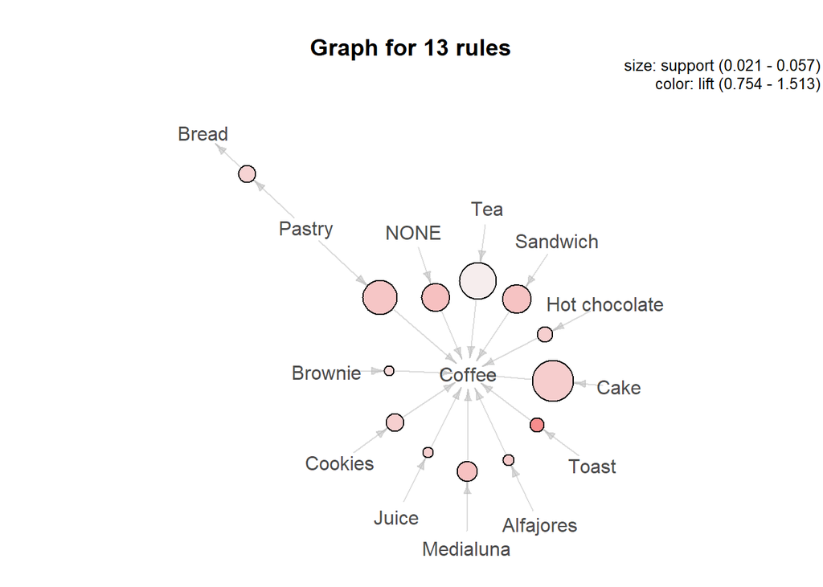

```r
plot(rules_eclat_2, method="graph", shading="lift")
```

Results described in a graphic way.

```r
plot(rules_eclat_2, method="graph", measure="support", shading="lift", engine="html")
```

[interactive chart not shown]

The same plot as above but in dynamic version.

# Apriori algorithm

In this part I try Apriori algorithm with the same support and confidence values as in Eclat algorithm.

```r
rules_apriori<-apriori(bakery, parameter=list(supp=0.02, conf=0.3))
```

```
## Apriori
##
## Parameter specification:
##  confidence minval smax arem  aval originalSupport maxtime support minlen
##         0.3    0.1    1 none FALSE            TRUE       5    0.02      1
##  maxlen target  ext
##      10  rules TRUE
##
## Algorithmic control:
##  filter tree heap memopt load sort verbose
##     0.1 TRUE TRUE  FALSE TRUE    2    TRUE
##
## Absolute minimum support count: 132
##
## set item appearances ...[0 item(s)] done [0.00s].
## set transactions ...[103 item(s), 6613 transaction(s)] done [0.00s].
## sorting and recoding items ... [22 item(s)] done [0.00s].
## creating transaction tree ... done [0.00s].
## checking subsets of size 1 2 3 done [0.00s].
## writing ... [15 rule(s)] done [0.00s].
## creating S4 object  ... done [0.00s].
```

```r
rules_apriori_i <-  inspect(head(sort(rules_apriori, by = "lift", decreasing = TRUE),15))
```

```r
kable(rules_apriori_i , "html") %>% kable_styling("striped")
```

|  | lhs |  | rhs | support | confidence | coverage | lift | count |
| --- | --- | --- | --- | --- | --- | --- | --- | --- |
| [1] | {Toast} | => | {Coffee} | 0.0257069 | 0.7296137 | 0.0352336 | 1.5134679 | 170 |
| [2] | {NONE} | => | {Coffee} | 0.0417360 | 0.5810526 | 0.0718282 | 1.2053015 | 276 |
| [3] | {Medialuna} | => | {Coffee} | 0.0329654 | 0.5751979 | 0.0573114 | 1.1931567 | 218 |
| [4] | {Sandwich} | => | {Coffee} | 0.0423408 | 0.5679513 | 0.0745501 | 1.1781249 | 280 |
| [5] | {Pastry} | => | {Coffee} | 0.0486920 | 0.5590278 | 0.0871012 | 1.1596144 | 322 |
| [6] | {Alfajores} | => | {Coffee} | 0.0223802 | 0.5522388 | 0.0405262 | 1.1455318 | 148 |
| [7] | {Cake} | => | {Coffee} | 0.0565553 | 0.5389049 | 0.1049448 | 1.1178727 | 374 |
| [8] | {Juice} | => | {Coffee} | 0.0213216 | 0.5300752 | 0.0402238 | 1.0995568 | 141 |
| [9] | {Cookies} | => | {Coffee} | 0.0297898 | 0.5267380 | 0.0565553 | 1.0926343 | 197 |
| [10] | {Hot chocolate} | => | {Coffee} | 0.0272191 | 0.5263158 | 0.0517163 | 1.0917586 | 180 |
| [11] | {Pastry} | => | {Bread} | 0.0296386 | 0.3402778 | 0.0871012 | 1.0485820 | 196 |
| [12] | {} | => | {Bread} | 0.3245123 | 0.3245123 | 1.0000000 | 1.0000000 | 2146 |
| [13] | {} | => | {Coffee} | 0.4820808 | 0.4820808 | 1.0000000 | 1.0000000 | 3188 |
| [14] | {Brownie} | => | {Coffee} | 0.0208680 | 0.4758621 | 0.0438530 | 0.9871003 | 138 |
| [15] | {Tea} | => | {Coffee} | 0.0517163 | 0.3634431 | 0.1422955 | 0.7539051 | 342 |

```r
rules_apriori
```

```
## set of 15 rules
```

The results are nearly the same as using Eclat algorithm. Difference occurs in a number of rules, because in Apriori there are 15 rules, while in Eclat 13 rules but 2 rules in Apriori are uninterpretable because lhs for them is equal to “{}” so conclusions from these two algorithms are the same. As I mentioned in previous part, Eclat algorithm is a more efficient and scalable version of the Apriori algorithm thus the decision which algorithm should be used depends of the dataset.

```r
plot(rules_apriori, method="graph", measure="support", shading="lift", engine="html")
```

[interactive chart not shown]

Plot for Apriori algorithm.

# Rules for particular product

Sometimes there is necessity to analyze particular product, not whole basket of products. In this part I focus on analyzing only one product.

```r
rules_bread<-apriori(data=bakery, parameter=list(supp=0.01,conf = 0.1),
                          appearance=list(default="lhs",rhs="Bread"), control=list(verbose=F))
rules_bread<-sort(rules_bread, by="support", decreasing=T)
inspect(head(rules_bread))
```

```
##     lhs         rhs     support    confidence coverage   lift      count
## [1] {}       => {Bread} 0.32451232 0.3245123  1.00000000 1.0000000 2146
## [2] {Coffee} => {Bread} 0.08982308 0.1863237  0.48208075 0.5741653  594
## [3] {Pastry} => {Bread} 0.02963859 0.3402778  0.08710116 1.0485820  196
## [4] {Tea}    => {Bread} 0.02948737 0.2072264  0.14229548 0.6385778  195
## [5] {Cake}   => {Bread} 0.02328746 0.2219020  0.10494481 0.6838015  154
## [6] {NONE}   => {Bread} 0.01875095 0.2610526  0.07182822 0.8044460  124
```

```r
rules_coffee<-apriori(data=bakery, parameter=list(supp=0.01,conf = 0.3, minlen=3),
                          appearance=list(default="lhs",rhs="Coffee"), control=list(verbose=F))
rules_coffee<-sort(rules_coffee, by="support", decreasing=T)
inspect(head(rules_coffee))
```

```
##     lhs               rhs      support    confidence coverage   lift      count
## [1] {Bread,Pastry} => {Coffee} 0.01134130 0.3826531  0.02963859 0.7937530 75
## [2] {Cake,Tea}     => {Coffee} 0.01119008 0.4277457  0.02616059 0.8872905 74
```

# Conclusions

Association rules are very useful in setting better strategy of product placement not only for huge companies but also for small businesses. In this project I have shown example use of the Eclat and Apriori algorithm to determine association rules for bakery. I have not focused on the results from my research, because this project is created to interest the reader with association rules not to explain fully what it is. If I have met my goal, here is one of many websites where you can acquire knowledge about association rules: https://towardsdatascience.com/association-rules-2-aa9a77241654